# NPS Power Simulations

Stephanie Chen

2023-03-16

This simulation cheat sheet is to help researchers approximate what sort of sample size they might need to estimate a population’s NPS with good accuracy.

### Sample Size Needed for 5 and 7% Margin of Error

The table approximates the sample size you need to get within 5 points of the true NPS 95% of the time you take a sample. I also plotted the sample size needed to get within 7 points of the true NPS, 95% of the time.

Based on the results, the sample you need depends on what the true NPS is. You can use prior experience/research and some critical thinking to guess at what that NPS might be.

Ballparked suggested sample sizes based on NPS:

| NPS.score | Sample.size.5pct.MOE | Sample.size.7pct.MOE |
| --- | --- | --- |
| 0 | 1250 | 600 |
| 20 | 1250 | 600 |
| 40 | 1000 | 500 |
| 50 | 1000 | 500 |
| 60 | 750 | 350 |
| 65 | 750 | 350 |
| 70 | 500 | 300 |
| 75 | 500 | 250 |
| 80 | 500 | 250 |
| 85 | 300 | 125 |

### Margin of Error Simulation Results

The plots below show the results.

Notes on how to read the plots:

- The black line shows the true NPS of that population
- The purple line shows the NPS score 5 points above the true NPS
- The red line shows the NPS score 7 points above the true NPS
- Where the shaded area and line intersect shows us what sample size we need to hit +/- 5 points (or +/- 7 points) from the true value 95% of the time.

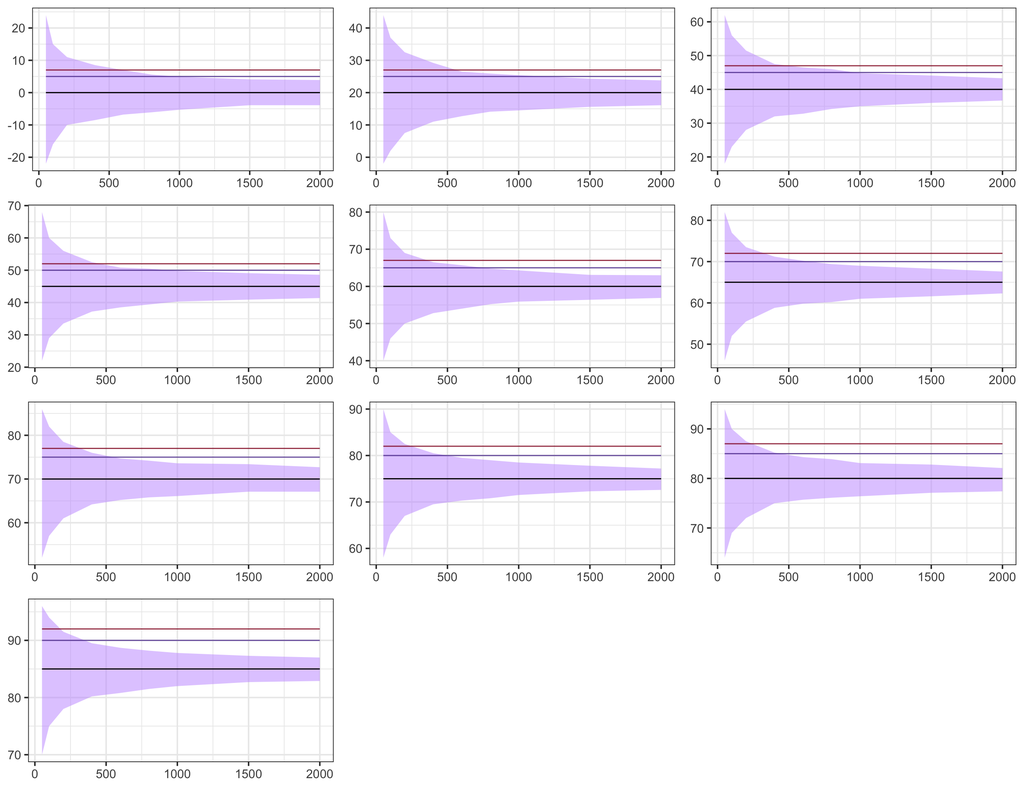

simulation results

### Simulation code

Step 1: Create the hypothetical “populations” that we will sample from and compute sample NPS. I will vary the NPS score of the population itself. NPS can be varied by changing the % promoters, % detractors, or both. I won’t simulate every potential population but will test some groups based on how we typically see NPS distributed for our main surveys.

```r
#set population to 50k. Can re-do simulation with different sizes if needed.
pop_size <- 50000

#set number of iterations you want for your simulations
times <- 1000

#sample sizes to test
sample_sizes <- c(50, 100, 200, 400, 600, 800, 1000, 1500, 2000)

#for population NPS of 85, I'll make 90% promoters, 5% passive, and 5% detractors

p85 <- c(rep("Promoter", .9 * pop_size),
         rep("Passive", .05 * pop_size),
         rep("Detractor", .05 * pop_size))

p80 <- c(rep("Promoter", .87 * pop_size),
         rep("Passive", .06 * pop_size),
         rep("Detractor", .07 * pop_size))

p75 <- c(rep("Promoter", .82 * pop_size),
         rep("Passive", .11 * pop_size),
         rep("Detractor", .07 * pop_size))

p70 <- c(rep("Promoter", .79 * pop_size),
         rep("Passive", .12 * pop_size),
         rep("Detractor", .09 * pop_size))

p65 <- c(rep("Promoter", .75 * pop_size),
         rep("Passive", .15 * pop_size),
         rep("Detractor", .1 * pop_size))

p60 <- c(rep("Promoter", .72 * pop_size),
         rep("Passive", .16 * pop_size),
         rep("Detractor", .12 * pop_size))

p45 <- c(rep("Promoter", .65 * pop_size),
         rep("Passive", .15 * pop_size),
         rep("Detractor", .20 * pop_size))
p40 <- c(rep("Promoter", .62 * pop_size),
         rep("Passive", .16 * pop_size),
         rep("Detractor", .22 * pop_size))

p20 <- c(rep("Promoter", .50 * pop_size),
         rep("Passive", .20 * pop_size),
         rep("Detractor", .30 * pop_size))


p0 <- c(rep("Promoter", .35 * pop_size),
         rep("Passive", .30 * pop_size),
         rep("Detractor", .35 * pop_size))


#these options are for testing same NPS scores but different distributions
p40_b <- c(rep("Promoter", .70 * pop_size),
         rep("Passive", 0 * pop_size),
         rep("Detractor", .30 * pop_size))


p0_b <- c(rep("Promoter", .1 * pop_size),
         rep("Passive", .8 * pop_size),
         rep("Detractor", .1 * pop_size))
```

Then I wrote some functions to do sampling and computing NPS, and getting the 95% intervals.

```r
nps <- function(x) {
  step1 <- length(x[x == "Promoter"])/length(x) * 100
  step2 <- length(x[x == "Detractor"])/length(x) * 100
  return(step1 - step2)
}

samp <- function(data_set, sample_size){
  output <- sample(data_set, sample_size, replace = F)
  return(output)
}

sample_function <- function(data_set, sample_size, num_iterations) {

  output <- replicate(num_iterations, samp(data_set, sample_size))
  output <- data.frame(
    output
  )

  return(output)
}

test_matrix <- sample_function(p45, 5, 10)

test_output <- apply(
    sample_function(p40, 10, 5),
    MARGIN = 2,
    FUN = nps)


#get median nps for all the samples you took, as well as the 95% confidence interval, which would be the NPS value at position .025 and .975
all_nps <- function(data_set, sample_size, num_iterations) {
  output <- apply(
    sample_function(data_set, sample_size, num_iterations),
    MARGIN = 2,
    FUN = nps) %>%
    sort()

    lower_position <- round(.025 * length(output), 0)
    upper_position <- round(.975 * length(output), 0)

    results <- data.frame(median_nps = round(median(output), 1),
                          lower_bound = round(output[lower_position], 1),
                          upper_bound = round(output[upper_position], 1)) %>%
      mutate(range = upper_bound - lower_bound)

  return(results)
}
```

Code for producing the results and the plots. I ran the simulations, saved the image, and knit the final file just reading in the image.

```r
plotres <- function(x, true_nps) {
  output <- ggplot(x, aes(sample_size, upper_bound)) +
  geom_ribbon(aes(ymin = lower_bound, ymax = upper_bound,
                  fill = "purple",
                alpha = .1)) +
  geom_line(aes(sample_size, true_nps + 7), #7% margin of error
            color = rktcol[1],
            alpha = .8) +
    geom_line(aes(sample_size, true_nps + 5), #5% margin of error
            color = rktcol[2],
            alpha = .8) +
  geom_line(aes(sample_size, true_nps), #true population NPS
            color = 'black') +
  theme_bw(base_size = 14) +
  theme(legend.position = "none",
        axis.title = element_blank()) +
  scale_fill_manual(values = rktcol[6])


  return(output)
}

#plots for each simulation results

make_the_plot <- function(data_set, true_nps) {
  sim_results <- data.frame(sample_size = sample_sizes,
                          median_nps = NA,
                          lower_bound = NA,
                          upper_bound = NA,
                          range = NA)

  for(i in 1:length(sample_sizes))
  sim_results[i, c(2:5)] <- all_nps(data_set, sample_sizes[i], times)

  output <- plotres(sim_results, true_nps)

  return(output)
}



#for sample of NPS = 0, 20, etc.
pp0 <- make_the_plot(p0, 0)
pp20 <- make_the_plot(p20, 20)
pp40 <- make_the_plot(p40, 40)
pp45 <- make_the_plot(p45, 45)
pp60 <- make_the_plot(p60, 60)
pp65 <- make_the_plot(p65, 65)
pp70 <- make_the_plot(p70, 70)
pp75 <- make_the_plot(p75, 75)
pp80 <- make_the_plot(p80, 80)
pp85 <- make_the_plot(p85, 85)

grid.arrange(pp0,
             pp20,
             pp40,
             pp45,
             pp60,
             pp65,
             pp70,
             pp75,
             pp80,
             pp85,
             ncol = 3)
```

### Check different distributions for MOE

The same NPS score can be produced by 2 different populations (for example, an NPS of 40 can result from 65% promoters - 25% detractors, *or* 45% promoters and 5% detractors). I ran my simulation keeping detractors and passives fairly balanced, since that is what I have observed with our typical NPS data. But do the required sample sizes for 5 and 7% margins of error change when the distribution producing the same NPS changes?

Let’s estimate the sample size needed for NPS = 40 (70% promoters, 30% detractors, 0 passives), and compare that to the original simulation of NPS = 40 (62% promoters, 22% detractors, 16% passive).

Let’s also estimate for an NPS = 0 (10% promoters, 10% detractors, 80% passives), compared to the original simulation of NPS = 0 (35% promoters, 35% detractors, 30% passive).

It may be that as you get closer to NPS = 0, the more passives you have (relative to the full distribution), the lower your sample size needs to be.

So there are 2 opposing forces at play for determining NPS sample size.

**One is NPS itself**.  
The closer to 100 (or -100), the smaller your sample size needs to be to get 5% margin of error. Conversely, the closer NPS is to 0, the larger your sample size needs to be to achieve 5% margin of error 95% of the time.

This makes sense: after you account for promoters, the remaining % of respondents logically have to split between detractors and passives. The closer NPS is to 100, logically the fewer remaining respondents you have to allocate to these other 2 groups. The extremes (both 100 and -100) constrict how many other types of respondents you can have.

**The other is share of passives (maybe).**  
As you get closer to 0, you can in theory have more room to alter how you split the remaining respondents (detractors vs passives). If you have a lower share of passives, the higher your sample size needs to be. If passives are more evenly split with detractors, then your sample size can be smaller. (That’s a hypothesis - I should simulate this more to test it.)

```r
new_table <- data.frame(group = c("Original NPS 40",
                       "New NPS 40",
                       "Original NPS 0",
                       "New NPS 0"),
             promoters_pct = c(62, 70, 35, 10),
             detractors_pct = c(22, 30, 35, 10),
             passive_pct = c(16, 0, 30, 80),
             recommended_n_5pct = c(1000, 1250, 1250, 400),
             recommended_n_7pct = c(500, 600, 600, 150))
new_table %>%
  kbl() %>%
  kable_paper(full_width = F)
```

| group | promoters_pct | detractors_pct | passive_pct | recommended_n_5pct | recommended_n_7pct |
| --- | --- | --- | --- | --- | --- |
| Original NPS 40 | 62 | 22 | 16 | 1000 | 500 |
| New NPS 40 | 70 | 30 | 0 | 1250 | 600 |
| Original NPS 0 | 35 | 35 | 30 | 1250 | 600 |
| New NPS 0 | 10 | 10 | 80 | 400 | 150 |

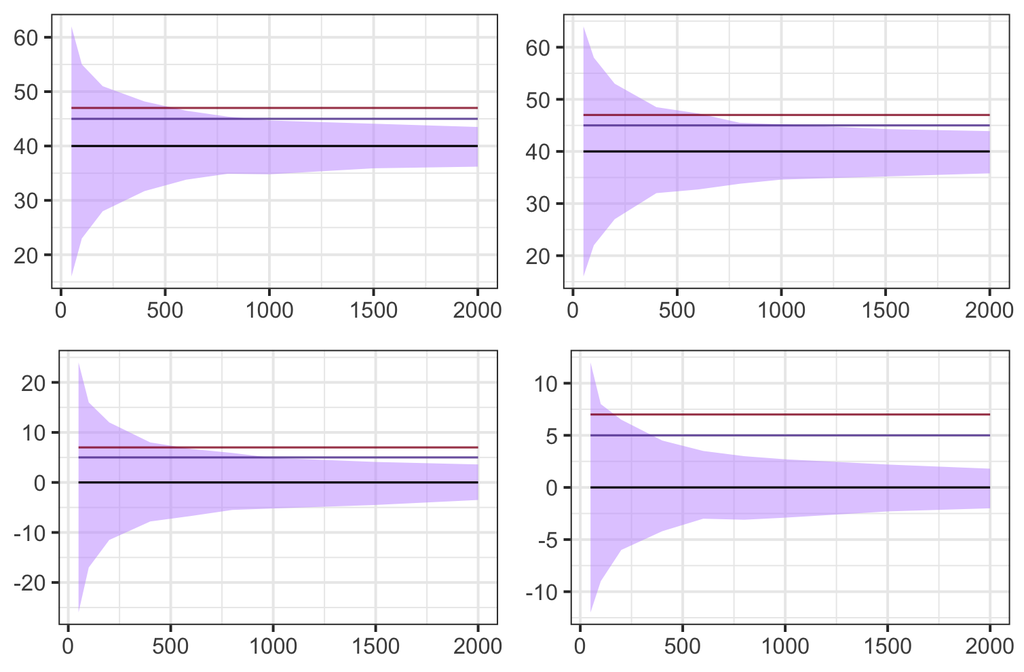

```r
#p40_b
pp40b <- make_the_plot(p40_b, 40)


#p0_b
pp0b <- make_the_plot(p0_b, 0)

grid.arrange(pp40, pp40b,
             pp0, pp0b,
             ncol = 2)
```